# Rapport

Biton Cherif SAKO/ 10-01-2026

2026-01-14

# Chargement des bibliothèques

```r
library(tidyverse)
library(doremifasolData)
library(knitr)
library(kableExtra)
library(scales)
library(ggthemes)
library(e1071) # pour le calcul du coefficient de skewness
```

```r
library(corrplot) # pour la matrice de corrélation des indicateurs des NA
```

# Chargement des bases de donnés

```r
#On renomme ici la variable com en CODGEO dans la base cog_com_2019
cog_com_2019_new <-  rename(cog_com_2019,CODGEO = com)

# Le numéro de mon département
dep_choisi <- 82

#La fusion de la base filosofi_com_2016 et de la variable "dep" de la base cog_com_2019 grâce à la variable CODGEO
tab_jointe <- filosofi_com_2016 %>%
  left_join(
    cog_com_2019_new,
    by = "CODGEO"
  )


#Création du  sous-ensemble donnees_dep qui ne contient que les communes de mon département (82).
donne_dep <- filter(tab_jointe, dep== 82)
```

*Dans cette partie, nous avons chargé les bases “filosofi_com_2016” et “cog_com_2019” . La base “tab_jointe” est la fusion de la base “filosofi_com_2016”(entièrement) et de la base “cog_com_2019_new”. Cette fusion a été réalisée grâce à variable commune” CODGEO”, qui était nommée “com” initialement dans la base “cog_com_2019”. Quant à la base “donne_dep”, c’est la base “tab_jointe” qui ne contient que les communes du département: 82.*

# Revue de la qualité des données

### A-) Visualisation Structure des bases

```r
str(filosofi_com_2016)
```

```
## 'data.frame':    34932 obs. of  29 variables:
##  $ CODGEO         : chr  "01001" "01002" "01004" "01005" ...
##  $ LIBGEO         : chr  "L'Abergement-Clémenciat" "L'Abergement-de-Varey" "Ambérieu-en-Bugey" "Ambérieux-en-Dombes" ...
##  $ NBMENFISC16    : num  313 101 6363 633 NA ...
##  $ NBPERSMENFISC16: num  796 248 14228 1662 NA ...
##  $ MED16          : num  22679 24382 19721 23378 NA ...
##  $ PIMP16         : num  NA NA 49 NA NA 57 NA NA NA NA ...
##  $ TP6016         : num  NA NA 17 NA NA NA NA NA NA NA ...
##  $ TP60AGE116     : num  NA NA 19 NA NA NA NA NA NA NA ...
##  $ TP60AGE216     : num  NA NA 22 NA NA NA NA NA NA NA ...
##  $ TP60AGE316     : num  NA NA 22 NA NA NA NA NA NA NA ...
##  $ TP60AGE416     : num  NA NA 15 NA NA NA NA NA NA NA ...
##  $ TP60AGE516     : num  NA NA 9 NA NA NA NA NA NA NA ...
##  $ TP60AGE616     : num  NA NA NA NA NA NA NA NA NA NA ...
##  $ TP60TOL116     : num  NA NA 5 NA NA NA NA NA NA NA ...
##  $ TP60TOL216     : num  NA NA 28 NA NA NA NA NA NA NA ...
##  $ PACT16         : num  NA NA 73 NA NA 75.5 NA NA NA NA ...
##  $ PTSA16         : num  NA NA 66 NA NA 70.5 NA NA NA NA ...
##  $ PCHO16         : num  NA NA 3.3 NA NA 2.5 NA NA NA NA ...
##  $ PBEN16         : num  NA NA 3.7 NA NA 2.6 NA NA NA NA ...
##  $ PPEN16         : num  NA NA 27 NA NA 27.2 NA NA NA NA ...
##  $ PPAT16         : num  NA NA 8.8 NA NA 8.1 NA NA NA NA ...
##  $ PPSOC16        : num  NA NA 6.9 NA NA 4.2 NA NA NA NA ...
##  $ PPFAM16        : num  NA NA 2.8 NA NA 2.4 NA NA NA NA ...
##  $ PPMINI16       : num  NA NA 2.1 NA NA 1 NA NA NA NA ...
##  $ PPLOGT16       : num  NA NA 2 NA NA 0.8 NA NA NA NA ...
##  $ PIMPOT16       : num  NA NA -15.7 NA NA -15 NA NA NA NA ...
##  $ D116           : num  NA NA 10457 NA NA ...
##  $ D916           : num  NA NA 33881 NA NA ...
##  $ RD16           : num  NA NA 3.24 NA NA ...
```

```r
str(cog_com_2019)
```

```
## 'data.frame':    37930 obs. of  11 variables:
##  $ typecom  : chr  "COM" "COM" "COM" "COM" ...
##  $ com      : chr  "01001" "01002" "01004" "01005" ...
##  $ reg      : chr  "84" "84" "84" "84" ...
##  $ dep      : chr  "01" "01" "01" "01" ...
##  $ arr      : chr  "012" "011" "011" "012" ...
##  $ tncc     : chr  "5" "5" "1" "1" ...
##  $ ncc      : chr  "ABERGEMENT CLEMENCIAT" "ABERGEMENT DE VAREY" "AMBERIEU EN BUGEY" "AMBERIEUX EN DOMBES" ...
##  $ nccenr   : chr  "Abergement-Clémenciat" "Abergement-de-Varey" "Ambérieu-en-Bugey" "Ambérieux-en-Dombes" ...
##  $ libelle  : chr  "L'Abergement-Clémenciat" "L'Abergement-de-Varey" "Ambérieu-en-Bugey" "Ambérieux-en-Dombes" ...
##  $ can      : chr  "0108" "0101" "0101" "0122" ...
##  $ comparent: chr  NA NA NA NA ...
##  - attr(*, "spec")=
##   .. cols(
##   ..   typecom = col_character(),
##   ..   com = col_character(),
##   ..   reg = col_character(),
##   ..   dep = col_character(),
##   ..   arr = col_character(),
##   ..   tncc = col_character(),
##   ..   ncc = col_character(),
##   ..   nccenr = col_character(),
##   ..   libelle = col_character(),
##   ..   can = col_character(),
##   ..   comparent = col_character()
##   .. )
```

*la visualisation de str(filosofi_com_2016) renvoie que la base filosofi_com_2016 contient 34932 observations et 29 variables. Parmis lesquelles seules les variables CODGEO et LIBGEO sont catégorielles,les 27 autres sont numériques*

*la visualisation de str(cog_com_2019) indique que la base cog_com_2019 contient 37930 observations et 11 variables.Toutes les 11 variables sont catégorielles*

# B-) Vérification des valeurs manquantes et leur traitement.

L’étude des valeurs manquantes se fera sur la base tab_jointe dû au fait qu’elle est la combinaison des deux bases cog_com_2019 et filosofi_com_2016. Elle contient toutes les variables nécessaires pour la suite du projet.

# B.1 ) Visualisation des valeurs manquantes par variable

```r
#Nombre total de NA de la base
sum(is.na(tab_jointe))
```

```
## [1] 801893
```

```r
# Fonction pour calculer la proportion de valeurs manquantes
prop_val_manq <- function(base){
  #Calcul du nombre de valeurs manquantes par colonne
  nb_val_man <- sapply(base, function(x) sum(is.na(x)))

  #Calcul de ma proportion de valeurs manquantes
  prop_NA <- (nb_val_man / nrow(base))*100

  #Création d'un dataframe pour le résultat
  resultat <- data.frame(Nombre_NA = nb_val_man, Proportion= prop_NA)
  return(resultat)
}
visual<- prop_val_manq(tab_jointe)
```

*sum(is.na(tab_jointe))=801893, donc le nombre total de valeurs manquantes dans la base tab_jointe est de 801893*

*Pour la variable dep et reg, les valeurs manquantes sont dûes au faite que certaines communes associées ont le même code géographique que leur commune principale donc lors de la création de tab_jointe, on se retrouve avec des doublons de communes ce qui cause la présence des valeurs manquantes.*

# B.2-) Vérification du types des valeurs manquantes

# a-) Visualisation de la matrice de corrélation des indicateurs de valeurs manquantes

Visualisation de la matrice de corrélation des indicateurs de valeurs manquantes se fera sur les variables qui interveneront dans la suite du projet.

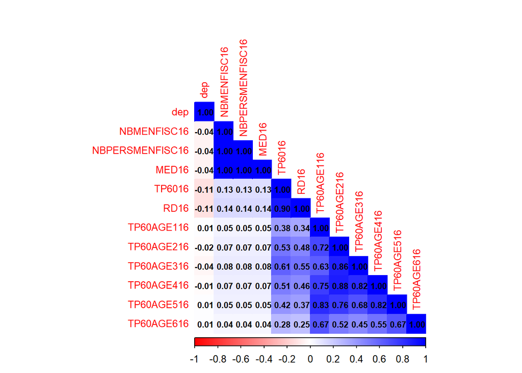

```r
#Selection des variables d'intérêt
Na_tab <- tab_jointe%>%
  select(dep,NBMENFISC16, NBPERSMENFISC16, MED16, TP6016, RD16,TP60AGE116, TP60AGE216, TP60AGE316, TP60AGE416, TP60AGE516, TP60AGE616)%>%
  mutate(across(everything(), ~ as.integer(is.na(.))))

#la corrélation entre les variables de Na_tab
correlation_na <- cor(Na_tab)

#la matrice de corrélation
matrice_corr <- corrplot(
  correlation_na,
  method = "color",
  type = "lower",
  addCoef.col = "black",
  tl.cex = 0.8,
  number.cex = 0.7,
  col = colorRampPalette(c("red", "white", "blue"))(200))
```

# B.3-) Traitement des NA

Les données de la base tab_jointe comportent des valeur manquantes, principalement liées sûrement à des effectifs communaux insuffisants. Dans ce travail, aucun procédé d’imputation ne sera appliqué afin d’éviter toute distorsion des indicateurs de revenu et de pauvreté afin d’éviter tout biais. Les statistiques descriptives et graphiques seront calculées en excluant uniquement les observations manquantes concernées en se limitant ainsi qu’aux communes renseignées. Mais nous traiterons les NA des variables dep et reg afin que les bases “tabjointe” et “donne_dep” ne contiennent que les communes principales.

```r
tab_jointe <- filter(tab_jointe, !is.na(dep))
donne_dep<- filter(donne_dep, !is.na(dep))
```

### C-) Vérification des doublons

```r
tab_jointe[duplicated(tab_jointe),]
```

```
##  [1] CODGEO          LIBGEO          NBMENFISC16     NBPERSMENFISC16
##  [5] MED16           PIMP16          TP6016          TP60AGE116
##  [9] TP60AGE216      TP60AGE316      TP60AGE416      TP60AGE516
## [13] TP60AGE616      TP60TOL116      TP60TOL216      PACT16
## [17] PTSA16          PCHO16          PBEN16          PPEN16
## [21] PPAT16          PPSOC16         PPFAM16         PPMINI16
## [25] PPLOGT16        PIMPOT16        D116            D916
## [29] RD16            typecom         reg             dep
## [33] arr             tncc            ncc             nccenr
## [37] libelle         can             comparent
## <0 lignes> (ou 'row.names' de longueur nulle)
```

*tab_jointe[duplicated(tab_jointe),] =0, alors il n’y a pas de doublons dans la base tab_jointe*

### D-) Résumé descriptive de la base tab_jointe

```r
summary(tab_jointe)
```

```
##     CODGEO             LIBGEO           NBMENFISC16        NBPERSMENFISC16
##  Length:34932       Length:34932       Min.   :     33.0   Min.   :     76.0
##  Class :character   Class :character   1st Qu.:    105.0   1st Qu.:    251.0
##  Mode  :character   Mode  :character   Median :    218.0   Median :    528.5
##                                        Mean   :    929.2   Mean   :   2131.3
##                                        3rd Qu.:    529.0   3rd Qu.:   1285.0
##                                        Max.   :1027657.0   Max.   :2074629.5
##                                        NA's   :3527        NA's   :3527
##      MED16           PIMP16          TP6016        TP60AGE116
##  Min.   :10932   Min.   :12.0    Min.   : 5.00   Min.   :10.00
##  1st Qu.:19024   1st Qu.:43.0    1st Qu.: 9.00   1st Qu.:21.00
##  Median :20452   Median :51.0    Median :12.00   Median :29.00
##  Mean   :20898   Mean   :52.2    Mean   :13.73   Mean   :29.36
##  3rd Qu.:22227   3rd Qu.:61.0    3rd Qu.:17.00   3rd Qu.:36.00
##  Max.   :48288   Max.   :88.0    Max.   :58.00   Max.   :66.00
##  NA's   :3527    NA's   :29639   NA's   :30560   NA's   :34173
##    TP60AGE216      TP60AGE316      TP60AGE416      TP60AGE516
##  Min.   : 5.00   Min.   : 5.00   Min.   : 5.00   Min.   : 5.00
##  1st Qu.:15.00   1st Qu.:14.00   1st Qu.:13.00   1st Qu.: 9.00
##  Median :22.00   Median :20.00   Median :18.00   Median :13.00
##  Mean   :23.24   Mean   :21.73   Mean   :19.04   Mean   :14.08
##  3rd Qu.:30.00   3rd Qu.:28.00   3rd Qu.:24.00   3rd Qu.:17.00
##  Max.   :65.00   Max.   :61.00   Max.   :57.00   Max.   :56.00
##  NA's   :33518   NA's   :33106   NA's   :33640   NA's   :34042
##    TP60AGE616      TP60TOL116       TP60TOL216        PACT16
##  Min.   : 5.0    Min.   : 5.000   Min.   : 8.0    Min.   : 15.00
##  1st Qu.: 8.0    1st Qu.: 5.000   1st Qu.:20.0    1st Qu.: 64.50
##  Median :10.0    Median : 7.000   Median :26.0    Median : 71.90
##  Mean   :13.5    Mean   : 8.468   Mean   :27.1    Mean   : 71.01
##  3rd Qu.:14.0    3rd Qu.:10.000   3rd Qu.:33.0    3rd Qu.: 78.40
##  Max.   :57.0    Max.   :57.000   Max.   :69.0    Max.   :103.60
##  NA's   :34529   NA's   :32777    NA's   :31758   NA's   :29639
##      PTSA16          PCHO16          PBEN16           PPEN16
##  Min.   :12.00   Min.   :1.10    Min.   : 0.400   Min.   : 7.70
##  1st Qu.:55.70   1st Qu.:2.60    1st Qu.: 3.600   1st Qu.:25.10
##  Median :63.50   Median :3.00    Median : 4.800   Median :29.30
##  Mean   :62.82   Mean   :3.12    Mean   : 5.072   Mean   :30.16
##  3rd Qu.:70.60   3rd Qu.:3.50    3rd Qu.: 6.200   3rd Qu.:34.30
##  Max.   :96.20   Max.   :8.40    Max.   :26.000   Max.   :69.80
##  NA's   :29639   NA's   :29639   NA's   :29639    NA's   :29639
```

[output cut: 25 more lines]

```
##  Length:34932       Length:34932       Length:34932       Length:34932
##  Class :character   Class :character   Class :character   Class :character
##  Mode  :character   Mode  :character   Mode  :character   Mode  :character
##
##
##
##
##    libelle              can             comparent
##  Length:34932       Length:34932       Length:34932
##  Class :character   Class :character   Class :character
##  Mode  :character   Mode  :character   Mode  :character
##
##
##
##
```

*summary(tab_jointe) renvoie le résumé des variables de la base tab_jointe*

# Introduction

Les facteurs socio-économiques tels que le revenus et la pauvreté constituent des enjeux majeurs en France avec des disparités territoriales. L’analyse statistique de ces phénomèes permet de mieux comprendre les conditions de vie entre ses territoires. Notre travail s’appuie sur les données communales issues de la base filosofi_com_2016 et cog_com_2019 de l’INSEE et vise à analyser la répartition des revenus et de la pauvreté à l’échelle nationale et départementale. De prime abord, nous effectuerons une analyse descriptive des données afin de mettre en évidence les principales disparités géographiques. Ensuite, nous developperons des fonctions pour comparer les distributions et les indicateurs du département 82 à ceux observé au niveau national. Enfin, une analyse aprofondie sera ménée afin d’interpréter les résultats obtenus au niveau du niveau de vie médian, de pauvreté et d’inégalités.

# PARTIE 1: Manipulation et Exploration des Données

## Exercice 1.1: Vue d’ensemble géographique

### A- Extraction des variables d’intérêts

```r
#Création d'une nouvelle base contenant le nombre de départements, le nombre de communes, le nombre de ménagesNombre d’habitants de toutes les régions
tab1 <- left_join(tab_jointe%>% select(CODGEO ,NBMENFISC16, NBPERSMENFISC16), cog_com_2019_new%>% select(CODGEO, reg,dep), by = "CODGEO")
```

*La table “tab1”, est un tableau joint avec les variables : CODGEO(l’identifiant des communes principales) ,NBMENFISC16 (le nombre de ménages), NBPERSMENFISC16 (le nombre d’habitants par ménage), tiré de la base initiale “filosofi_com_2016”. Et avec les varibles:CODGEO (l’indentifiant des communes principales et associées), reg(l’identifiant des régions) et dep(l’identifiant des départements) tiré de la base “cog_com_2019_new”.*

### B- Groupage par régions

```r
#Création et groupage de tabe2 par région
tab2 <- tab1%>%
  group_by(reg) %>%
  summarise(nb_depart = n_distinct(dep),
            nb_commune = n(),
            nb_menage = sum(NBMENFISC16, na.rm = T),
            nb_habitant = sum(NBPERSMENFISC16, na.rm = T)
            )

 #Triage de tab2 par ordre décroissant de la population et l'ajout de la variable "libelle" qui contient les noms des régions
tab2 <- tab2 %>%
  arrange(desc(nb_habitant))

#Ajout de la ligne totale
tab2 <- add_row(tab2,
                reg = "Total",
                nb_depart = sum(tab2$nb_depart),
                nb_commune = sum(tab2$nb_commune),
                nb_menage = sum(tab2$nb_menage),
                nb_habitant = sum(tab2$nb_habitant))
```

*Dans cette partie, nous avons groupé les variables : “dep”, “CODGEO”, “NBMENFISC16”, et “NBPERSMENFISC16” en fonction des régions.La base “tab2” est le tableau regroupant toutes ces variables en fonction de chaque région*

### C- Tableau récapitualtif et Interprétation

```r
#Utilisation de kable sur tab2
tab2%>%
  kable(
    format = "html",
    caption = "<span style='color:darkblue; font-weight:bold;'>Tableau récapitulatif</span>" ,
    format.args = list(big.mark = " ")
  ) %>%
  kable_styling(
    bootstrap_options = c("striped", "hover", "condensed"),
    full_width = FALSE
  ) %>%
  add_header_above(c(" " = 1, "Valeurs" = 4)) %>%
   row_spec(0:16, bold = TRUE, color = "black", background = "lightblue") %>%
  column_spec(1:5, bold = TRUE,italic = TRUE, border_right = T)%>%
  column_spec(1, border_left = T) %>%
  row_spec(1:16, extra_css = "border-bottom: 1px solid black;")%>%
  row_spec(0, extra_css = "border-top: 2px solid black; border-bottom: 2px solid black;")%>%
  row_spec(16, extra_css = "border-bottom: 2px solid black;")
```

Tableau récapitulatif

| reg | Valeurs nb_depart | Valeurs nb_commune | Valeurs nb_menage | Valeurs nb_habitant |
| --- | --- | --- | --- | --- |
| 11 | 8 | 1 288 | 5 911 506 | 13 986 361.0 |
| 84 | 12 | 4 038 | 3 556 042 | 8 113 515.5 |
| 93 | 6 | 962 | 2 585 964 | 5 798 175.0 |
| 32 | 5 | 3 789 | 2 407 622 | 5 796 382.0 |
| 75 | 12 | 4 314 | 2 607 906 | 5 722 411.5 |
| 76 | 13 | 4 453 | 2 499 274 | 5 541 107.5 |
| 44 | 10 | 5 115 | 2 298 330 | 5 245 007.5 |
| 52 | 5 | 1 238 | 1 576 800 | 3 657 592.5 |
| 53 | 4 | 1 206 | 1 439 970 | 3 225 233.0 |
| 28 | 5 | 2 650 | 1 406 613 | 3 213 842.0 |
| 27 | 8 | 3 704 | 1 203 187 | 2 667 496.5 |
| 24 | 6 | 1 758 | 1 110 551 | 2 512 872.0 |
| NA | 1 | 677 | 961 397 | 2 246 785.0 |
| 04 | 1 | 24 | 307 206 | 850 081.0 |
| 02 | 1 | 34 | 148 960 | 341 866.0 |
| 94 | 2 | 359 | 120 333 | 260 298.5 |
| Total | 99 | 35 609 | 30 141 661 | 69 179 026.5 |

*L’observation du tableau récaptulatif met en évidence de fortes disparités régionales en termes de population et de structure territoriale avec une réparation asymétrique de la population par région. L’Île-de-France(reg 11) se distingue clairement à travers son nombre d’hibitants très élevé et concentré sur un nombre limité de communes, ce qui traduit une forte densité urbaine. A l’inverse, certaines régions moins peuplées regroupent un grand nombre de communes tel que Bourgogne-Franche-Comté(reg 27), révélant ainsi une région plus rurale et dispersé. Ces différences marquées dans l’organisation spatiale et démographique des régions françaises sont susceptibles d’influencer les niveaux de vie et les conditions socio-économiques.*

## Exercice 1.2: Analyse des niveaux de vie

### A- La répartition nationale du taux de pauvreté par tranche d’âge

#### A.1- Extraction des vriables d’intérêt

```r
# Création d'une nouvelle base tab_poor_natio qui contiendra les taux de pauvreté par tranche d'âge de toute la France
 tab_poor_natio <- left_join(tab1 %>% select(CODGEO,dep), tab_jointe%>% select(CODGEO, TP60AGE116,TP60AGE216,TP60AGE316, TP60AGE416,TP60AGE516, TP60AGE616), by="CODGEO")


 # Ici on renomme les variables des tranches d'âge
 names(tab_poor_natio)[names(tab_poor_natio) %in% c("TP60AGE116","TP60AGE216","TP60AGE316", "TP60AGE416","TP60AGE516", "TP60AGE616")] <-
  c("age_0_30","age_30_39","age_40_49","age_50_59","age_60_74","age_75")
```

#### A.2- Groupage du taux de pauvreté par tranche d’âge sur le territoire national

```r
# Calcul des moyennes
taux_moy_de_poor<- tab_poor_natio %>%
  summarise(
    age_0_30 = mean(age_0_30, na.rm = T),
    age_30_39 = mean(age_30_39, na.rm = T),
    age_40_49 = mean(age_40_49, na.rm = T),
    age_50_59 = mean(age_50_59, na.rm = T),
    age_60_74 = mean(age_60_74, na.rm = TRUE),
    age_75 = mean( age_75, na.rm = TRUE)
  )

# On passe du format large au format long
tab_poor_natio_lon <- tab_poor_natio%>%
  pivot_longer(
    cols = c(age_0_30,age_30_39,age_40_49,age_50_59,age_60_74,age_75),
    names_to = "tranche_age",
    values_to = "taux_moy_de_poor")


#Groupage par tranche d'âge des moyennes pondérées
tab_poor_fianl <- tab_poor_natio_lon%>%
  group_by(tranche_age)%>%
  summarise(moy_nationale = mean(taux_moy_de_poor, na.rm = T))
```

#### A.3- Visualisation de la répartition nationale du taux de pauvreté par tranche d’âge

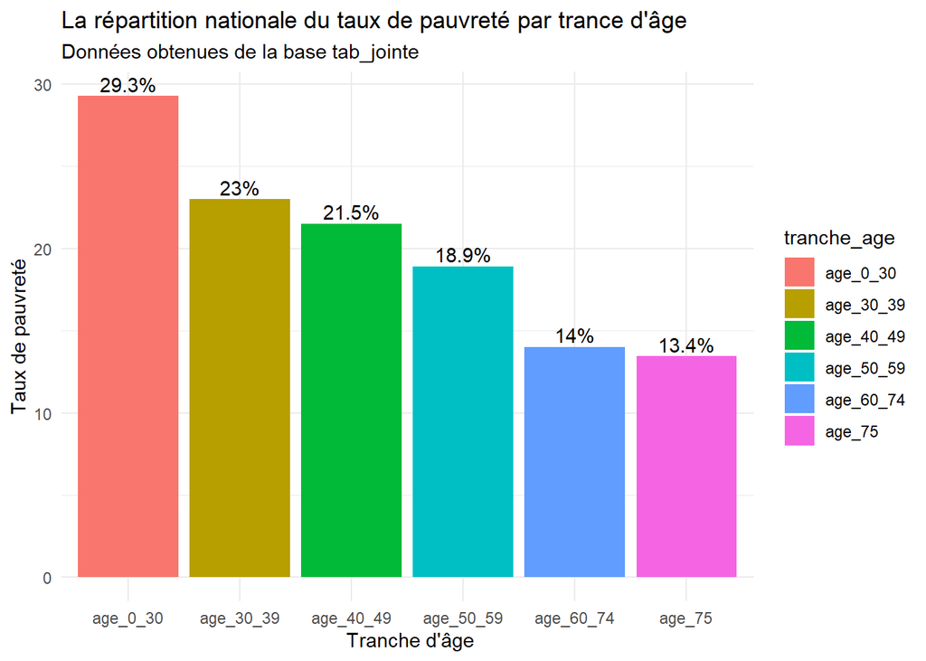

```r
ggplot(tab_poor_fianl, aes(x=tranche_age, y=moy_nationale,fill= tranche_age))+
geom_bar(stat = "identity") +
  geom_text(aes(label = paste0(round(moy_nationale, 1), "%")),vjust = -0.3,) +
  labs(
    title="La répartition nationale du taux de pauvreté par trance d'âge",
  subtitle = "Données obtenues de la base tab_jointe",
       x = " Tranche d'âge",
  y= "Taux de pauvreté"
       )+
theme_minimal()
```

### B- Répartition départementale du taux de pauvreté par tranche d’âge

#### B.1- Groupage des départements en fonction des tranches d’âges

```r
#Création d'une nouvelle base :les départements en fonction des tranches d'âge
val_extreme1 <- tab_poor_natio|>
  pivot_longer(cols = c( "age_0_30", "age_30_39", "age_40_49", "age_50_59", "age_60_74", "age_75"),
               names_to = "tranche_age",
               values_to = "taux_pauvrete") |>
  group_by(tranche_age) |>
  summarise(
    dep_min = dep[which.min(taux_pauvrete)],
    taux_min = min(taux_pauvrete, na.rm = T),
    dep_max = dep[which.max(taux_pauvrete)],
    taux_max = max(taux_pauvrete, na.rm = T))

#On passe du format large au format long
val_extreme2 <- val_extreme1 |>
  pivot_longer(
    cols = c(taux_min, taux_max),
    names_to = "Type_taux",
    values_to = "Taux_poor")
```

#### B.2- Visualisation du graphique comparatif pour les extrêmes départementaux

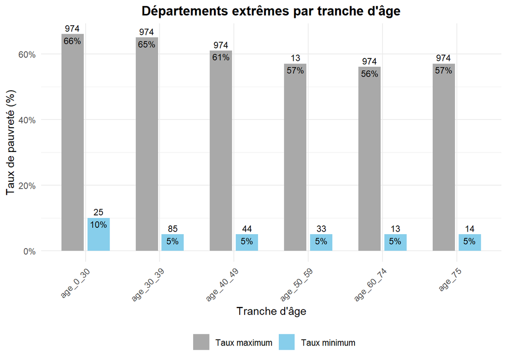

```r
val_extreme2 <- val_extreme2 |>
  mutate(
    code_dep = if_else(Type_taux == "taux_min", dep_min, dep_max),
    categorie = if_else(Type_taux == "taux_min", "Taux minimum", "Taux maximum")
  )

ggplot(val_extreme2, aes(x = tranche_age, y = Taux_poor, fill = categorie)) +
  geom_col(position = position_dodge(width = 0.7), width = 0.6) +
  geom_text(aes(label = paste0(code_dep, "\n", round(Taux_poor, 1), "%")),
            position = position_dodge(width = 0.7), size = 3) +
  scale_y_continuous(labels = scales::percent_format(scale = 1)) +
  scale_fill_manual(values = c("Taux minimum" = "skyblue", "Taux maximum" = "darkgray")) +
  labs(
    title = "Départements extrêmes par tranche d'âge",
    x = "Tranche d'âge",
    y = "Taux de pauvreté (%)",
    fill = ""
  ) +
  theme_minimal() +
  theme(
    legend.position = "bottom",
    plot.title = element_text(hjust = 0.5, face = "bold"),
    axis.text.x = element_text(angle = 45, hjust = 1))
```

# Partite 2 : Les fonctions

## Exercice 2.1: Comparaison des distributions (la fonction : f.distrib() )

```r
f.distrib <- function(data, caractere, dep_select){

  # Nettoyage de la base de données data afin d'avaoir uniquement que les départements principaux sans les NA au niveau de la variable d'intérêt
  data <- data %>%
    filter(!is.na({{ caractere }}), !is.na(dep))

  # var_name sctoke le nom de la variable d'intérêt
  var_name <- rlang::as_name(rlang::ensym(caractere))

  # Création d'une nouvelle variable dans la base data qui devient data1 "identifiant" de type caractère qui prend comme modalité "Département_et le numéro du département d'intérêt" si dep== dep_select sinon, elle prend "Toute la France"
  data1 <- data %>%
    mutate(identifiant = ifelse(dep == dep_select,
        paste0("Département ", dep_select),
        "Toute la France"))


  # Graphique de la densité
  p_densite <- ggplot(data1, aes(x= {{caractere}})) +
    geom_density(fill = "lightblue", color = "white")+
    facet_wrap(~identifiant, nrow = 1, scales = "free_y") +
    labs(
      title = paste("Courbe de densité de", var_name),
      x = var_name
    ) +
    theme_minimal()


  # Boxplot comparatif
  p_box <- ggplot(data1, aes(x =identifiant, y ={{ caractere }})) +
  geom_boxplot(fill ="lightblue") +
  labs(
    title = paste("Boxplot comparatif de", var_name),
    x = "",
    y = var_name
  ) +
  theme_minimal()

# data_dep est une nouvelle base qui ne contient que les modalités de la variable d'intérêt du départemetent choisi
  data_dep <- data1 %>%
    filter(dep == dep_select) %>%
    pull({{ caractere }})
  # data_france est une nouvelle base qui ne contient que les modalités de la variable d'intérêt de toute la france sauf du dep82
  data_france <- data1 %>%
  filter(dep != dep_select) %>%
  pull({{ caractere }})

# le test de symétrie de skew_val et l'interprétation
  skew_val <- abs(skewness(data_dep, na.rm = TRUE))
  interpretation <- case_when(skew_val <=0.1 ~ "La distribution départementale est quasi symétrique"
                              ,skew_val >0.1 & skew_val <=0.5 ~ "La distribution départementale est faiblement asymétrique",
    TRUE ~ "La distribution départementale est asymétrie"
  )

  #Le test de Shapiro-wilk pour vérifier la normalité de la distribution de la variable d'intérêt
  shapiro_dep<- shapiro.test(data_dep)

  #Interpréation de la p_value du test de Shapiro
  inter_normalite_dep <- case_when(shapiro_dep$p.value < 0.05 ~ "L'hypothèse de normalité est rejetée",
                                   shapiro_dep$p.value > 0.05 ~ "L'hypothèse de non normalité est rejetée")


  return(list(
    densité = p_densite,
     boxplot = p_box,
    coefficient_d_asymetrie = skew_val,
    interpretation_asymetrie= interpretation,
    p_value_dep = shapiro_dep,
    interpretation_normalite_departemental= inter_normalite_dep))
}
```

*La fonction f.distrib permet de visualiser la distribution d’un caractère continu. En effet, la fonction renvoie deux courbes de densités dont l’une présente l’asymétrie de la distribution du caratère d’intérêt de la France entière et l’autre celle d’un département quelconque. f.distrib renvoie également deux boxplots dont l’un présente la visualisation de la distribution du caractère d’intérêt de la France et l’autre celle d’un département quelconque.De plus, elle renvoie le coefficient d’asymétrie de skewness afin de déterminer si la distribution au niveau du département choisi de la variable d’intérêt est symétrique ou pas.*

## Exercice 2.2: Analyse et comparaison

```r
 f.anal <- function(data, caractere, dep_select){
  data <- data %>%
    filter(!is.na({{ caractere }}), !is.na(dep))

  data1 <- data %>% select(dep,NBPERSMENFISC16,{{caractere}})

  var_name <- rlang::as_name(rlang::ensym(caractere))

  data_dep1 <- data1%>%
    filter(dep == dep_select)

  moy_natio <- mean(data1[[var_name]],na.rm = T)
  moy_dep   <- mean(data_dep1[[var_name]],na.rm = T)
  med_natio <- median(data1[[var_name]], na.rm =T)
  med_dep   <- median(data_dep1[[var_name]], na.rm =T)
  sd_natio  <- sd(data1[[var_name]], na.rm =T)
  sd_dep    <- sd(data_dep1[[var_name]], na.rm =T)
  min_natio <- min(data1[[var_name]], na.rm =T)
  min_dep   <- min(data_dep1[[var_name]], na.rm =T)
  max_natio <- max(data1[[var_name]], na.rm =T )
  max_dep   <- max(data_dep1[[var_name]], na.rm =T)
  q1_natio  <- quantile(data1[[var_name]], 0.25, na.rm =T)
  q1_dep    <- quantile(data_dep1[[var_name]], 0.25, na.rm =T)
  q3_natio  <- quantile(data1[[var_name]], 0.75, na.rm =T)
  q3_dep    <- quantile(data_dep1[[var_name]], 0.75, na.rm =T)

  data2 <- data1%>%
    group_by(dep)%>%
    summarise(!!var_name:= mean({{caractere}}, na.rm=T))

  data3<- data2 %>%
    arrange(desc(!!sym(var_name))) %>%
    mutate(rang = row_number()
    )

  rang_dep <- data3 %>% filter(dep == dep_select) %>% pull(rang)

  data1_sans_dep <- data1 %>% filter(dep!= dep_select)

  p_value<- wilcox.test(data_dep1[[var_name]],data1_sans_dep[[var_name]],alternative = "two.sided")$p.value

  nom_dep <- paste("Département", dep_select)

  interpretation <- case_when(
    p_value < 0.05 & med_dep< med_natio ~ paste(var_name, "est inférieure face à la France"),
    p_value < 0.05 & med_dep> med_natio ~ paste(var_name,"est supérieure face à la France"),
    T ~ paste(var_name,"est équivalente à la France")
  )

  data_resume <- tibble::tibble(
    indicateur =c("Moyenne", "Médiane", "Écart-type", "Minimum", "Maximum",
                  "1er quartile", "3e quartile", "Rang", "La p_value","Interprétation","Total"),
    La_France =c(moy_natio, med_natio, sd_natio, min_natio, max_natio,
                 q1_natio, q3_natio, NA, NA,NA,sum(data1$NBPERSMENFISC16,na.rm=T)
    ),
    !!nom_dep:=c(moy_dep, med_dep, sd_dep, min_dep, max_dep,
                 q1_dep, q3_dep, rang_dep, p_value, interpretation,sum(data_dep1$NBPERSMENFISC16,na.rm =T))
  )

  tab_final <- data_resume%>%
    kable(
      format = "html",
      caption = paste("Résumé pour le caractère", var_name),
      format.args = list(big.mark = " ", decimal.mark = ",")
    ) %>%
    kable_styling(
      bootstrap_options = c("striped", "hover", "condensed"),
      full_width = F
    ) %>%
    row_spec(0:11, bold = TRUE, color = "black", background = "lightblue") %>%
    column_spec(1:3, bold = TRUE,italic = TRUE, border_right = T)%>%
    column_spec(1, border_left = T) %>%
    row_spec(1:11, extra_css = "border-bottom: 1px solid black;")%>%
    row_spec(0, extra_css = "border-top: 2px solid black; border-bottom: 2px solid black;")%>%
    row_spec(11, extra_css = "border-bottom: 2px solid black;")

  return(knitr::asis_output(tab_final))

}
```

*La fonction f.anal renvoie un tableau comparatif du niveau national par rapport au niveau du département d’intérêt pour un caractère donné.Ici, le test de Wilcoxon est le mieux adapté car, il compare la distribution communale du département à celle des communes des autres départements, à partir des données brutes.*

# Partie 3

## 3.1 Description des indicateurs soci-économiques tel que le niveau de vie médian, le taux de pauvreté et enfin le rapport interdécile du département 82

### A- Analyse du niveau de vie médian

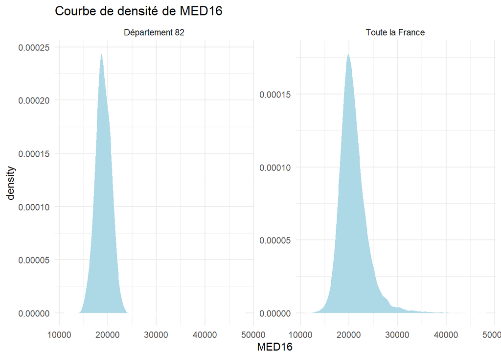

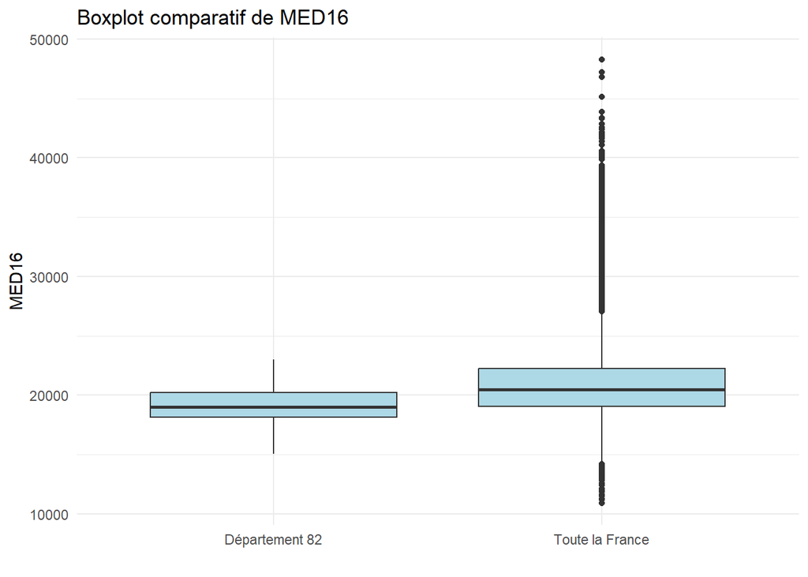

```
##
## $coefficient_d_asymetrie
## [1] 0.006289674
##
## $interpretation_asymetrie
## [1] "La distribution départementale est quasi symétrique"
##
## $p_value_dep
##
##  Shapiro-Wilk normality test
##
## data:  data_dep
## W = 0.99672, p-value = 0.9646
##
##
## $interpretation_normalite_departemental
## [1] "L'hypothèse de non normalité est rejetée"
```

```r
f.distrib(tab_jointe,MED16,dep_choisi)
```

```r
f.anal(tab_jointe,MED16,dep_choisi)
```

Résumé pour le caractère MED16

| indicateur | La_France | Département 82 |
| --- | --- | --- |
| Moyenne | 20 898,029 | 19055.4870623114 |
| Médiane | 20 452,381 | 19008.6666666667 |
| Écart-type | 2 991,949 | 1531.93253164549 |
| Minimum | 10 932,000 | 15084 |
| Maximum | 48 288,095 | 23009.1666666667 |
| 1er quartile | 19 024,167 | 18126.6666666667 |
| 3e quartile | 22 226,667 | 20198.4791666667 |
| Rang | NA | 86 |
| La p_value | NA | 8.46863813202449e-23 |
| Interprétation | NA | MED16 est inférieure face à la France |
| Total | 66 932 241,500 | 252237.5 |

*L’analyse du niveau de vie dans le département 82, réalisée à l’aide des fonctions f.distrib() et f.anal(), met en évidence une distribution communale approximativement symétrique, comme l’indique le coefficient d’asymétrie de skewness très proche de 0 (0,006).Le test de Shapiro indique également qu’à 95% de certitude, cette distribution est normale (p-value = 0.9646). Cette observation est confirmée par la courbe de densité et le boxplot, qui ne révèlent pas de dissymétrie marquée.* *Par ailleurs, le boxplot ne met pas en évidence de valeurs aberrantes significatives.* *Le tableau de synthèse indique que le département se situe au 86ᵉ rang sur 98 départements en termes de niveau de vie moyen.*

### B- Analyse de la pauvreté

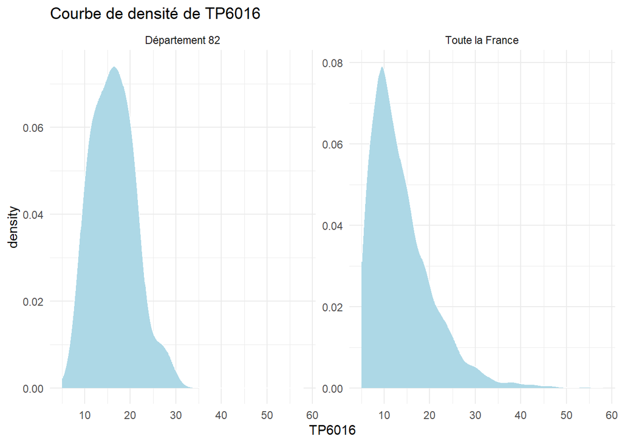

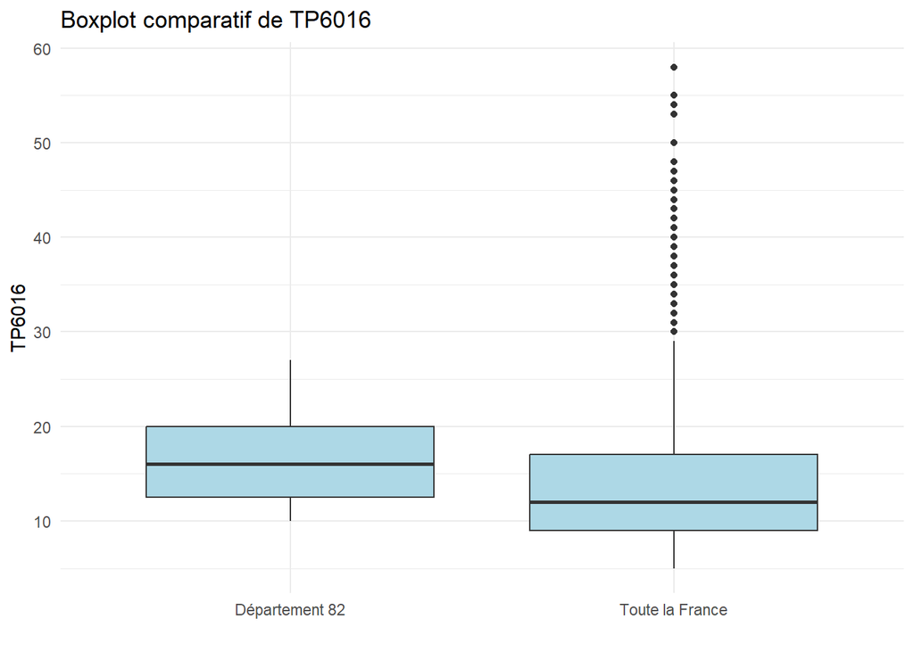

```
##
## $coefficient_d_asymetrie
## [1] 0.4227347
##
## $interpretation_asymetrie
## [1] "La distribution départementale est faiblement asymétrique"
##
## $p_value_dep
##
##  Shapiro-Wilk normality test
##
## data:  data_dep
## W = 0.94476, p-value = 0.3206
##
##
## $interpretation_normalite_departemental
## [1] "L'hypothèse de non normalité est rejetée"
```

```r
f.distrib(tab_jointe,TP6016, dep_choisi)
```

```r
f.anal(tab_jointe,TP6016, dep_choisi)
```

Résumé pour le caractère TP6016

| indicateur | La_France | Département 82 |
| --- | --- | --- |
| Moyenne | 1,373422e+01 | 16.2105263157895 |
| Médiane | 1,200000e+01 | 16 |
| Écart-type | 6,846240e+00 | 4.55313014881486 |
| Minimum | 5,000000e+00 | 10 |
| Maximum | 5,800000e+01 | 27 |
| 1er quartile | 9,000000e+00 | 12.5 |
| 3e quartile | 1,700000e+01 | 20 |
| Rang | NA | 23 |
| La p_value | NA | 0.00989907501013396 |
| Interprétation | NA | TP6016 est supérieure face à la France |
| Total | 4,970273e+07 | 151492.5 |

*L’analyse du taux de pauvreté dans le département 82, réalisée à l’aide des fonctions f.distrib() et f.anal(), met en évidence une distribution communale présentant une faible asymétrie, comme l’indique un coefficient de skewness positif de 0,42.Le test de Shapiro indique également qu’à 95% de certitude, cette distribution est normale(p-value = 0.3206). Cette observation est cohérente avec les graphiques produits, notamment la courbe de densité et le boxplot, qui suggèrent une distribution relativement équilibrée du taux de pauvreté entre les communes du département.* *Par ailleurs, le boxplot ne met pas en évidence de valeurs aberrantes marquées, bien qu’il révèle une dispersion importante entre les communes présentant les taux de pauvreté les plus faibles et les plus élevés.* *Le tableau de synthèse indique que le département se situe au 23ᵉ rang sur 98 départements en termes de taux de pauvreté, ce qui le place parmi les départements relativement plus touchés par la pauvreté.*

### C - Analyse du rapport interdécile

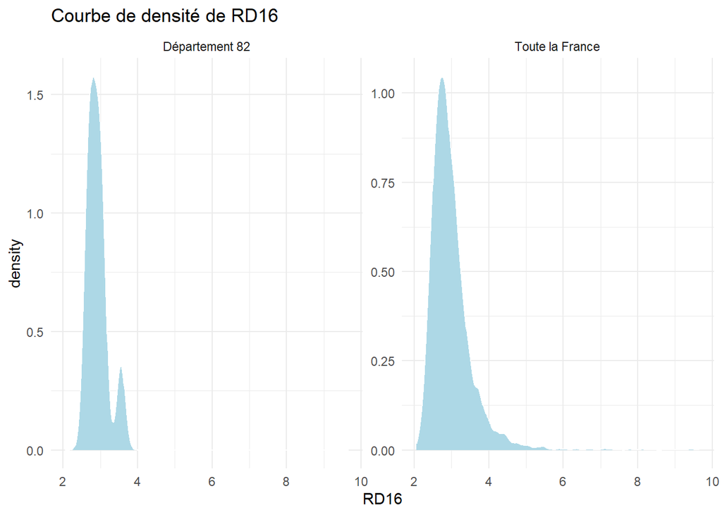

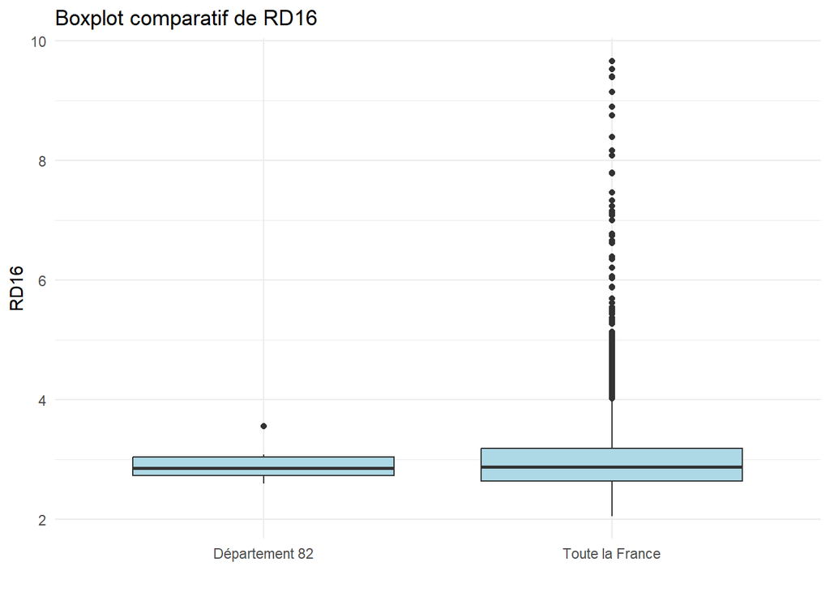

```
##
## $coefficient_d_asymetrie
## [1] 1.074701
##
## $interpretation_asymetrie
## [1] "La distribution départementale est asymétrie"
##
## $p_value_dep
##
##  Shapiro-Wilk normality test
##
## data:  data_dep
## W = 0.86679, p-value = 0.01274
##
##
## $interpretation_normalite_departemental
## [1] "L'hypothèse de normalité est rejetée"
```

```r
f.distrib(tab_jointe,RD16, dep_choisi)
```

```r
f.anal(tab_jointe,RD16, dep_choisi)
```

Résumé pour le caractère RD16

| indicateur | La_France | Département 82 |
| --- | --- | --- |
| Moyenne | 2,993386e+00 | 2.91904977581415 |
| Médiane | 2,870051e+00 | 2.85660583801887 |
| Écart-type | 6,089833e-01 | 0.270490468463777 |
| Minimum | 2,051327e+00 | 2.59107162206089 |
| Maximum | 9,666542e+00 | 3.55054490493994 |
| 1er quartile | 2,634210e+00 | 2.72706750479159 |
| 3e quartile | 3,185433e+00 | 3.04046604007352 |
| Rang | NA | 52 |
| La p_value | NA | 0.903692697017303 |
| Interprétation | NA | RD16 est équivalente à la France |
| Total | 5,211326e+07 | 151492.5 |

*L’analyse du rapport interdécile dans le département 82, réalisée à l’aide des fonctions f.distrib() et f.anal(), met en évidence une distribution communale présentant une asymétrie , comme l’indique un coefficient de skewness supérieur à 1 (1,07).Le test de Shapiro indique également qu’à 95% de certitude, cette distribution est anormale de p-value = 0.01274. Cette caractéristique est confirmée par la courbe de densité et le boxplot, qui révèlent une concentration des communes autour de valeurs relativement faibles, associée à quelques communes présentant des rapports interdéciles nettement plus élevés.* *Le boxplot met en évidence la présence d’une observation extrême unique, correspondant à une commune dont le rapport interdécile est nettement plus élevé que celui des autres communes du département.* *Le tableau de synthèse indique que le département se situe au 52ᵉ rang sur 98 départements en termes de rapport interdécile, ce qui le place dans une position intermédiaire au niveau national.*

## 3.2 Les questions statistiques

- Le niveau de vie médian dans le département82 est-il significativement différent de celui observé au niveau national?
- Le taux de pauvreté du département82 est-il plus élevé que la moyenne nationale?
- Le rapport interdécile (D9/D1) indique-t-il des inégalités de revenus plus fortes ou plus faibles entre les communes du département82 ?
- Les communes présentant des inégalités plus fortes sont-elles aussi celles où le taux de pauvreté est plus élevé ?

## 3.3 Plan d’analyse

Pour analyser la situation socio-économique du département82, nous utiliserons les variables issues de la base tab_jointe, notamment le niveau de vie médian (MED16), le taux de pauvreté (TP6016), le rapport interdécile (RD16), la variable département (dep) et enfin le nombre de personnnes par ménage (NBPERSMENFISC16). La fonction f.distrib() sera utilisée pour comparer les distributions communales du département82 à celles observées au niveau national, à l’aide des graphiques en facettes. Les courbes de densité permettront d’étudier la forme des distributions, tandis que les boxplots mettront en évidence la dispersion des modalités et les valeurs extrêmes. La fonction f.anal() produira des tableaux de comparaison synthétisant les caractéristiques de position et de dispersion, ainsi que le rang du département82. Des tests statistiques non paramétriques de Wilcoxon seront utilisés afin d’évaluer la significativité des écarts observés entre le département82 et le reste de la France.Pour l’analyse bivariée, un test de spearman sera utilisée afin d’analyser la corrélation entre les variables. En plus du test de Spearman, un modèle linéaire simple sera mis en place pour étudier la causalité de la variable explicative sur la variable expliquée, un nuage de point viendra confirmé ou pas nos analyses. L’ensemble de ces outils permettra de répondre aux questions portant sur le niveau de vie, la pauvreté et les inégalités de revenus.

# Partie 4: Analyse Approfondie de votre département

Nous allons d’abord extraire quelques informations du département 82 à savoir le nombre de communes le constituant, le nombre de ménages et de population.

```r
info_dep82 <- tab_jointe%>%
  filter(dep== dep_choisi)%>%
  summarise(nb_commune = n(),
            n_menage= sum(NBMENFISC16, na.rm = T),
            nb_population = sum(NBPERSMENFISC16, na.rm = T))
```

Le département82 compte 195 communes avec une population totale de 252238 habitants répartis dans  
107185 ménages

## A-) Analyse du niveau de vie (MED16)

```r
f.anal(tab_jointe, MED16, dep_choisi)
```

Résumé pour le caractère MED16

| indicateur | La_France | Département 82 |
| --- | --- | --- |
| Moyenne | 20 898,029 | 19055.4870623114 |
| Médiane | 20 452,381 | 19008.6666666667 |
| Écart-type | 2 991,949 | 1531.93253164549 |
| Minimum | 10 932,000 | 15084 |
| Maximum | 48 288,095 | 23009.1666666667 |
| 1er quartile | 19 024,167 | 18126.6666666667 |
| 3e quartile | 22 226,667 | 20198.4791666667 |
| Rang | NA | 86 |
| La p_value | NA | 8.46863813202449e-23 |
| Interprétation | NA | MED16 est inférieure face à la France |
| Total | 66 932 241,500 | 252237.5 |

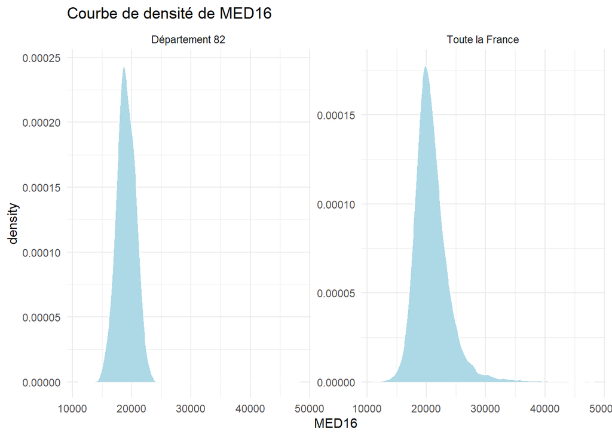

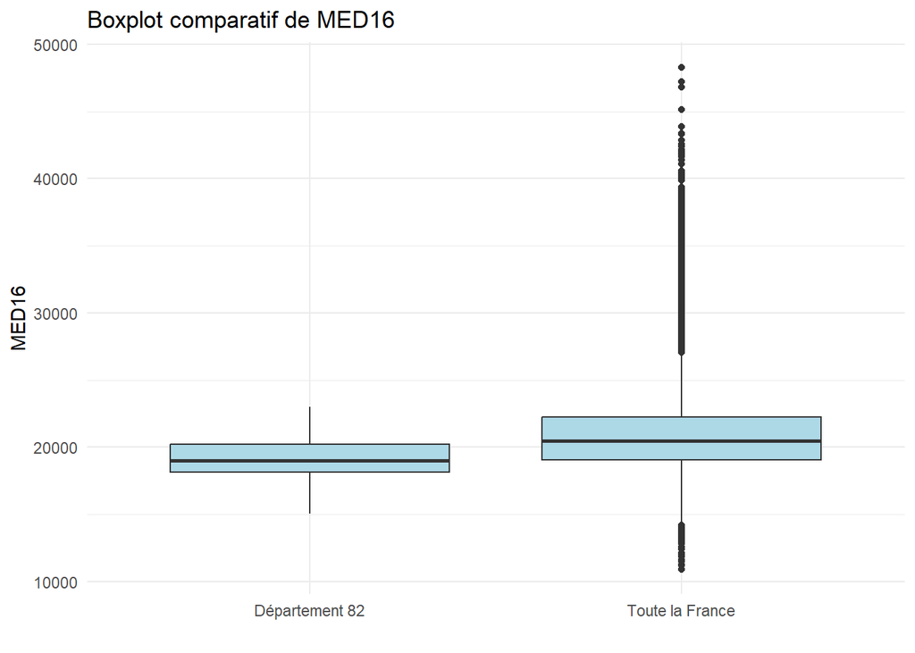

```
##
## $coefficient_d_asymetrie
## [1] 0.006289674
##
## $interpretation_asymetrie
## [1] "La distribution départementale est quasi symétrique"
##
## $p_value_dep
##
##  Shapiro-Wilk normality test
##
## data:  data_dep
## W = 0.99672, p-value = 0.9646
##
##
## $interpretation_normalite_departemental
## [1] "L'hypothèse de non normalité est rejetée"
```

```r
f.distrib(tab_jointe, MED16, dep_choisi)
```

*Le tableau de synthèse indique que le niveau de vie médian du département82 est inférieur au niveau de vie national. Se situant au 86ᵉ rang sur 98 départements,il présente une situation économique relativement moins favorable. Ce qui indique que les revenus des ménages y sont plus modestes que dans le reste de la France. Cette situation peut s’expliquer par une structure économique plus rurale, une présence faibles d’emplois qualifiés ou de secteurs économique à forte valeur ajoutée, ainsi qu’un dynamisme économique moins marqué que dans les grandes villes.* *La dispersion des niveaux de vie entre communes reste toutefois modérée, ce qui suggère une certaine homogénéité interne.Dit autrement, le département82 ne semble pas être caractérisé par de fortes oppositions entre les communes très riches et très pauvres, mais plutôt par un ensemble de territoires présentant des niveaux de vies proches. Cela s’explique par le fait que le département82 est constitué de communes à dominance rurale.* *La visualisation de la courbe de densité du niveau de vie médian du département82 met en évidence une distribution communale approximativement symétrique, comme l’indique le coefficient d’asymétrie de skewness très proche de 0 (0,0063).Cela confirme l’idée d’un département relativement équilibrée, sans présence marquée de communes extrêmement favorisées ou défavorisées.*

### B-) Analyse du taux de pauvreté (TP6016)

```r
f.anal(tab_jointe, TP6016, dep_choisi)
```

Résumé pour le caractère TP6016

| indicateur | La_France | Département 82 |
| --- | --- | --- |
| Moyenne | 1,373422e+01 | 16.2105263157895 |
| Médiane | 1,200000e+01 | 16 |
| Écart-type | 6,846240e+00 | 4.55313014881486 |
| Minimum | 5,000000e+00 | 10 |
| Maximum | 5,800000e+01 | 27 |
| 1er quartile | 9,000000e+00 | 12.5 |
| 3e quartile | 1,700000e+01 | 20 |
| Rang | NA | 23 |
| La p_value | NA | 0.00989907501013396 |
| Interprétation | NA | TP6016 est supérieure face à la France |
| Total | 4,970273e+07 | 151492.5 |

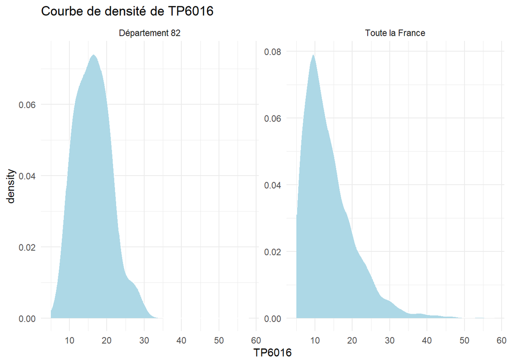

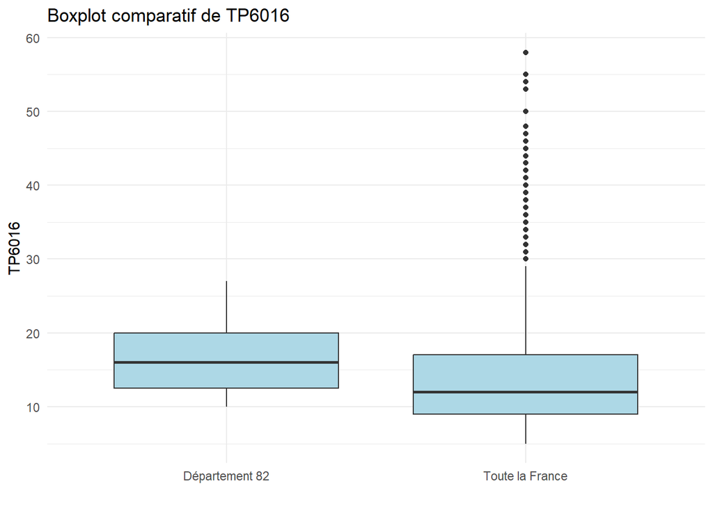

```
##
## $coefficient_d_asymetrie
## [1] 0.4227347
##
## $interpretation_asymetrie
## [1] "La distribution départementale est faiblement asymétrique"
##
## $p_value_dep
##
##  Shapiro-Wilk normality test
##
## data:  data_dep
## W = 0.94476, p-value = 0.3206
##
##
## $interpretation_normalite_departemental
## [1] "L'hypothèse de non normalité est rejetée"
```

```r
f.distrib(tab_jointe, TP6016, dep_choisi)
```

*Le taux de pauvreté du département82 est supérieur à celui observé au niveau national, ce qui traduit une situation sociale plus fragile. Il se situe au 23ᵉ rang sur 98 départements en termes de taux de pauvreté, ce qui confirme cette position relativement défavorable. Cela indique qu’une proportion plus importante de ménages y vit sous le seuil de pauvreté. Cette situation s’explique par une structure économique moins dynamique, un marché du travail plus restreint ou une plus forte présence d’emplois peu qualifiés et faiblement rémunérés.* *La dispersion observée entre les communes indique l’existence de contrastes internes, avec certaines communes nettement plus touchées par la pauvreté que d’autres. Ces écarts peuvent être liés à des différences d’accès à l’emploi, à la présence de pôles économiques locaux ou, au contraire, à des territoires plus isolés et moins attractifs.* *L’analyse du taux de pauvreté dans le département 82 par le biais de la courbe de densité met en évidence une distribution communale présentant une faible asymétrie, comme l’indique un coefficient de skewness positif de 0,42. Par ailleurs, le boxplot ne met pas en évidence de valeurs aberrantes marquées, bien qu’il révèle une dispersion importante des difficultés économiques entre les communes présentant les taux de pauvreté les plus faibles et les plus élevés.*

## C-) Analyse du Rapport interdécile (RD16)

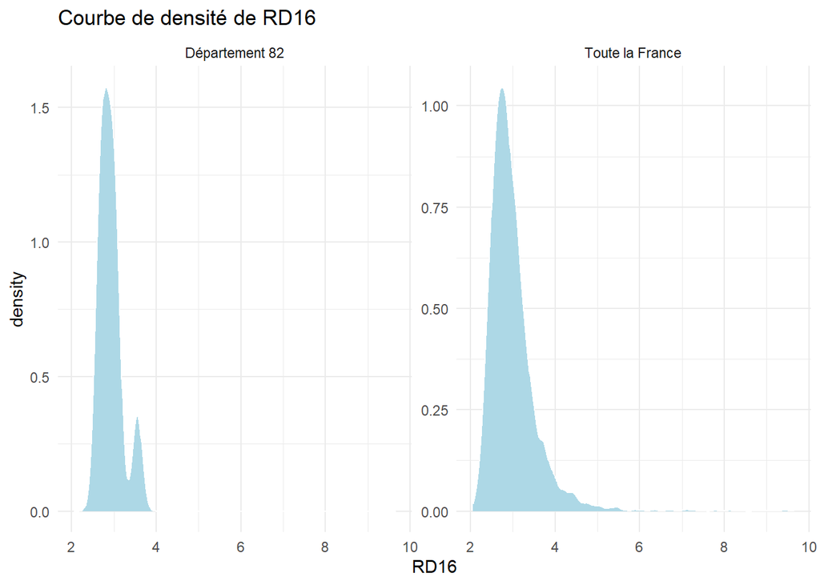

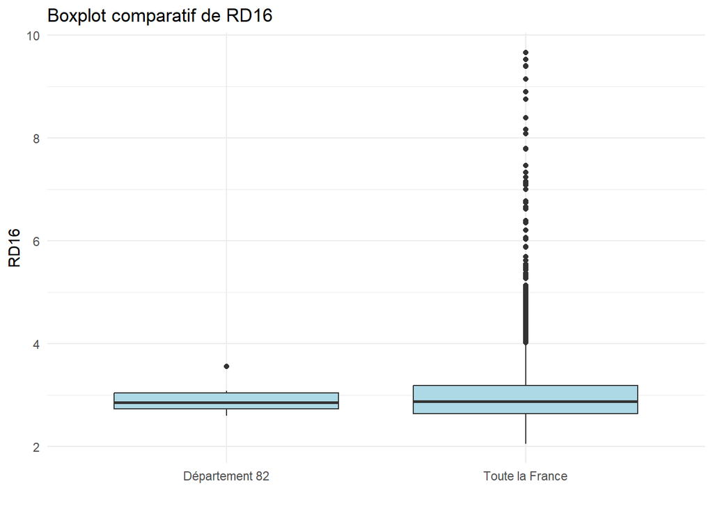

```
##
## $coefficient_d_asymetrie
## [1] 1.074701
##
## $interpretation_asymetrie
## [1] "La distribution départementale est asymétrie"
##
## $p_value_dep
##
##  Shapiro-Wilk normality test
##
## data:  data_dep
## W = 0.86679, p-value = 0.01274
##
##
## $interpretation_normalite_departemental
## [1] "L'hypothèse de normalité est rejetée"
```

```r
 f.distrib(tab_jointe, RD16, dep_choisi)
```

## D-) Les communes présentant des inégalités plus fortes sont-elles aussi celles où le taux de pauvreté est plus élevé ?

#Modele de regression linéaire simple

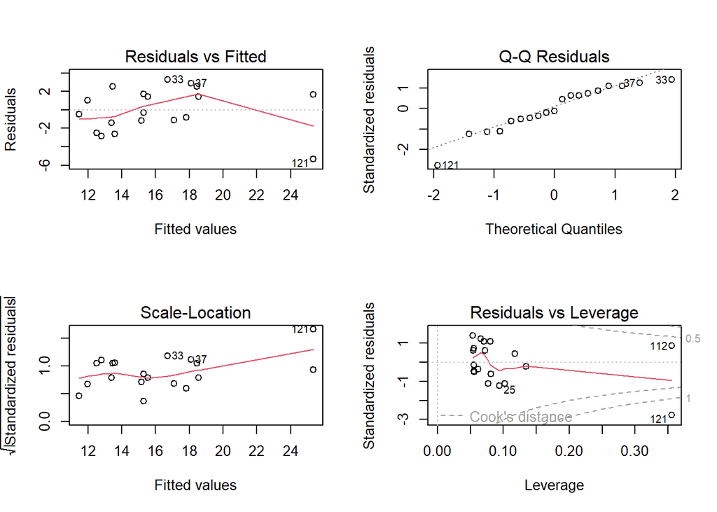

```r
model1 <- lm(TP6016 ~ RD16,data = donne_dep )
par(mfrow = c(2,2))
plot(model1)
```

```r
test_normalite1 <- shapiro.test(residuals(model1))$p.value
test_normalite1
```

```
## [1] 0.3670942
```

```r
summary(model1)
```

```
##
## Call:
## lm(formula = TP6016 ~ RD16, data = donne_dep)
##
## Residuals:
##    Min     1Q Median     3Q    Max
## -5.334 -1.303 -0.308  1.680  3.280
##
## Coefficients:
##             Estimate Std. Error t value Pr(>|t|)
## (Intercept)  -25.981      6.133  -4.237 0.000556 ***
## RD16          14.454      2.092   6.908 2.53e-06 ***
## ---
## Signif. codes:  0 '***' 0.001 '**' 0.01 '*' 0.05 '.' 0.1 ' ' 1
##
## Residual standard error: 2.401 on 17 degrees of freedom
##   (176 observations effacées parce que manquantes)
## Multiple R-squared:  0.7373, Adjusted R-squared:  0.7219
## F-statistic: 47.72 on 1 and 17 DF,  p-value: 2.534e-06
```

Nuage de point entre les inégalités et le taux de pauvreté du département 82

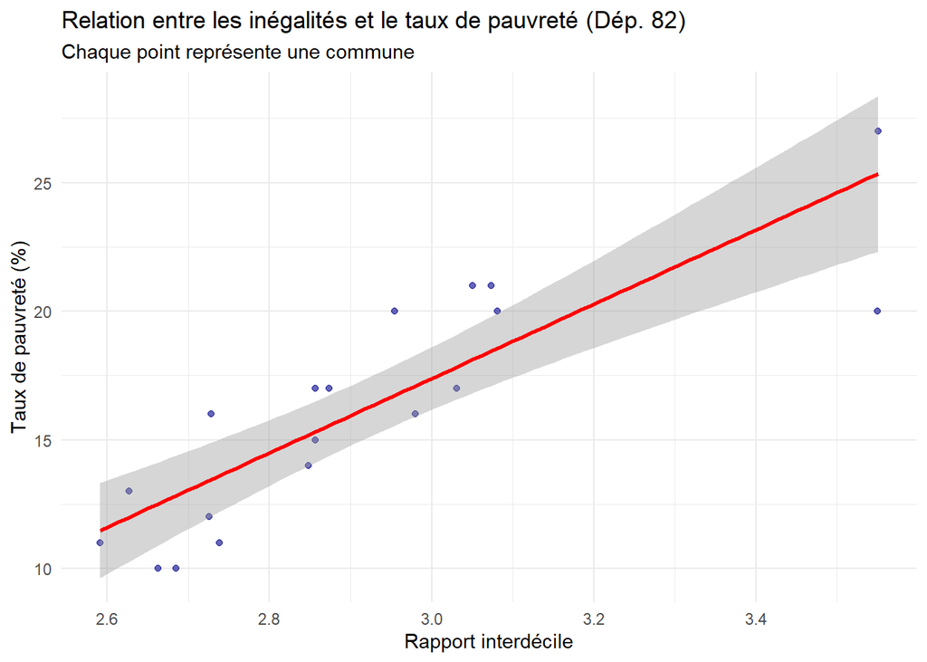

```r
# Graphique bivarié
donne_dep%>%
  ggplot(aes(x = RD16, y = TP6016)) +
  geom_point(alpha = 0.6, color = "darkblue", na.rm=T) +
  geom_smooth(method = "lm", se = TRUE, color = "red",na.rm=T) +
  labs(
    title = "Relation entre les inégalités et le taux de pauvreté (Dép. 82)",
    subtitle = "Chaque point représente une commune",
    x = "Rapport interdécile",
    y = "Taux de pauvreté (%)"
  ) +
  theme_minimal()
```

Le test de Shapiro Wilk indique une normalité de la distribution de la variable TP6016 dont la p-value = 0.3206 contrairement à la variable RD16 dont la distribution ne semble pas être normale avec une p-value = 0.01274. Donc le test de Pearson n’est pas adapté. Procedons au test de spearman.

```r
 coef_spearman <- cor(x = donne_dep$RD16,y = donne_dep$TP6016, method = "spearman",
                     use = "complete.obs")
coef_spearman
```

```
## [1] 0.896838
```

*Cette analyse bivariée met en évidence une forte corrélation positive entre le niveau d’inégalités et le taux de pauvreté des communes du département 82, qui confirmée par le modèle à 72% et par le coefficientde spearman (0.896838). En effet, les communes présentant un rapport interdécile plus élevé tendent à afficher des taux de pauvreté plus importants, ce qui suggère que les écarts de revenus impactent fortement le train de vie des ménages. Ceux sont des territoires où il existe un écart très important entre les groupes sociaux.Les inégalités internes peuvent alors traduire une segmentation du marché du travail ou une répartition inégale des opportunités économiques entre les communes. À l’inverse, les communes où les inégalités sont plus faibles présentent souvent des taux de pauvreté plus modérés, ce qui correspond à des structures sociales plus homogènes. Cette relation suggère que, dans le département, les territoires les plus inégalitaires sont également ceux où la fragilité sociale est la plus marquée.*

## Synethèse

# Conclusion

Ce projet m’a permis de mieux maîtriser l’utilisation de R pour l’analyse de données, notamment à travers la création et l’utilisation de fonctions pour automatiser les analyses descriptives et bivariées. J’ai également compris l’importance de structurer le code de manière claire et cohérente afin de faciliter son interprétation et sa réutilisation. L’utilisation d’un document R Markdown s’est révélée particulièrement utile pour assurer la reproductibilité du travail, en combinant dans un même fichier le code, les résultats et les commentaires. Cela permet de vérifier facilement les analyses et de reproduire les résultats dans les mêmes conditions. Enfin, ce projet m’a permis de mieux comprendre les indicateurs de niveau de vie, de pauvreté et d’inégalités, ainsi que les différences territoriales qui existent entre les départements et les communes françaises. L’analyse a montré l’intérêt de croiser plusieurs indicateurs pour obtenir une vision plus complète de la situation socio-économique d’un territoire. En résumé, ce projet m’a fait progresser en R, en rigueur et en analyse de données.

# Annexe